# Heterogeneous Data Analysis & String Similarity and Data Cleaning

## Overview

In this lab, you will compute the similairty between different strings and sets. You will use different atomic similarity measures. Moreover, you will practice to find the similarity between different sets using traditional similarity (Jaccard similarity, Sørensen Coefficient, Tversky Index and the Overlap Coefficient). Furthermore, you will handle data quality problems such as missing values, noisy data and outliers.

## 1. Atomic String Similarity

In the following exercises, you will learn about finding the simiarity between atomic values using Edit-Distance, Jaro Similarity, Jaro-Winkler Similarity and Soundex). We will start by importing the required libraries.

```
import pandas as pd
import csv
import numpy as np
```

Minimum Edit Distance (Levenshtein)

```
'''
TODO: find an implementation of the Levenshtein minimum edit distance and use it
to find the similarity between INTENTION and EXECUTION
'''
def ldist(s, t):
    """
        iterative_levenshtein(s, t) -> ldist
        ldist is the Levenshtein distance between the strings
        s and t.
        For all i and j, dist[i,j] will contain the Levenshtein
        distance between the first i characters of s and the
        first j characters of t
    """

    rows = len(s)+1
    cols = len(t)+1
    dist = [[0 for x in range(cols)] for x in range(rows)]

    # source prefixes can be transformed into empty strings
    # by deletions:
    for i in range(1, rows):
        dist[i][0] = i

    # target prefixes can be created from an empty source string
    # by inserting the characters
    for i in range(1, cols):
        dist[0][i] = i

    for col in range(1, cols):
        for row in range(1, rows):
            if s[row-1] == t[col-1]:
                c = 0
            else:
                c = 2
            dist[row][col] = min(dist[row-1][col] + 1,       # deletion
                                 dist[row][col-1] + 1,       # insertion
                                 dist[row-1][col-1] + c)     # substitution

    for r in range(rows):
        print(dist[r])


    return dist[row][col]

print("Minimum edit disctance = ", ldist("INTENTION", "EXECUTION"))
```

Output

```
[0, 1, 2, 3, 4, 5, 6, 7, 8, 9]
[1, 2, 3, 4, 5, 6, 7, 6, 7, 8]
[2, 3, 4, 5, 6, 7, 8, 7, 8, 7]
[3, 4, 5, 6, 7, 8, 7, 8, 9, 8]
[4, 3, 4, 5, 6, 7, 8, 9, 10, 9]
[5, 4, 5, 6, 7, 8, 9, 10, 11, 10]
[6, 5, 6, 7, 8, 9, 8, 9, 10, 11]
[7, 6, 7, 8, 9, 10, 9, 8, 9, 10]
[8, 7, 8, 9, 10, 11, 10, 9, 8, 9]
[9, 8, 9, 10, 11, 12, 11, 10, 9, 8]
Minimum edit disctance =  8
```

```
'''
TODO: Modify the ldist function to accept a new parameter which specifies the substitution cost
Test your implementation with the call mod_ldist("Intention", "execution", 1) -- You should get 5
and mod_ldist("Intention", "execution", 2) -- You should get 8
'''
def mod_ldist(s, t, substitution_cost):
    """
        iterative_levenshtein(s, t) -> ldist
        ldist is the Levenshtein distance between the strings
        s and t.
        For all i and j, dist[i,j] will contain the Levenshtein
        distance between the first i characters of s and the
        first j characters of t
    """

    rows = len(s)+1
    cols = len(t)+1
    dist = [[0 for x in range(cols)] for x in range(rows)]

    # source prefixes can be transformed into empty strings
    # by deletions:
    for i in range(1, rows):
        dist[i][0] = i

    # target prefixes can be created from an empty source string
    # by inserting the characters
    for i in range(1, cols):
        dist[0][i] = i

    for col in range(1, cols):
        for row in range(1, rows):
            if s[row-1] == t[col-1]:
                c = 0
            else:
                c = substitution_cost
            dist[row][col] = min(dist[row-1][col] + 1,       # deletion
                                 dist[row][col-1] + 1,       # insertion
                                 dist[row-1][col-1] + c)     # substitution

    return dist[row][col]

print("Minimum edit disctance = ", mod_ldist("INTENTION", "EXECUTION", 2))
```

Output

```
Minimum edit disctance =  8
```

Jaro Similarity

```
'''
TODO: find an implementation of the Jaro similarity algorithm and use it
to find the similarity between the follwing pairs of strings:
('nichlseon','niechlson'),
('MARTHA', 'MARHTA'),
('DIXON', 'DICKSONX'),
('JELLYFISH', 'SMELLYFISH'),
('cunningham', 'cunnigham'),
('shackleford', 'shackelford'),
('nichleson', 'nichulson'),
('arnab', 'urban'),
('DATASCIENCE','SCIENCEDATA')
'''
def jaro(s, t):
    '''Jaro similarity between two strings.'''
    s_len = len(s)
    t_len = len(t)

    if s_len == 0 and t_len == 0:
        return 1

    match_distance = (max(s_len, t_len) // 2) - 1

    s_matches = [False] * s_len
    t_matches = [False] * t_len

    matches = 0
    transpositions = 0

    for i in range(s_len):
        start = max(0, i - match_distance)
        end = min(i + match_distance + 1, t_len)

        for j in range(start, end):
            if t_matches[j]:
                continue
            if s[i] != t[j]:
                continue
            s_matches[i] = True
            t_matches[j] = True
            matches += 1
            break

    if matches == 0:
        return 0

    k = 0
    for i in range(s_len):
        if not s_matches[i]:
            continue
        while not t_matches[k]:
            k += 1
        if s[i] != t[k]:
            transpositions += 1
        k += 1

    return ((matches / s_len) +
            (matches / t_len) +
            ((matches - transpositions / 2) / matches)) / 3
```

Jaro-Winkler Similarity

```
'''
TODO: find an implementation of the Jaro-Winkler similarity algorithm and use it
to find the similarity between the pairs of strings in the previous exercise.
Compare the results and comment on them.
'''
def jaro_winkler(s, t, p = 0.1):
    # Compute the Jaro similarity
    jaro_sim = jaro(s, t)
    ls = len(s)
    lt = len(t)
    # Initialize the upper bound for the no. of prefixes.
    min_l = min(ls, lt)

    # Compute the prefix matches.
    l = 0
    for i in range(min_l):
        if s[i] == t[i]:
            l += 1
        else:
            break
    # Return the similarity value.
    L = min(l, 4)
    return (jaro_sim + ( L * p * (1 - jaro_sim) ))
```

```
# Test the functions on a set of strings
for s, t in [('nichlseon','niechlson'),
            ('MARTHA', 'MARHTA'),
            ('DIXON', 'DICKSONX'),
            ('JELLYFISH', 'SMELLYFISH'),
            ('cunningham', 'cunnigham'),
            ('shackleford', 'shackelford'),
            ('nichleson', 'nichulson'),
            ('arnab', 'urban'),
            ('DATASCIENCE','SCIENCEDATA')
        ]:
    print("jaro(%r, %r) = %.4f  and jaro-winkler(%r, %r) = %.4f" % (s, t, jaro(s, t), s, t, jaro_winkler(s, t)))
```

Output

```
jaro('nichlseon', 'niechlson') = 0.9259  and jaro-winkler('nichlseon', 'niechlson') = 0.9407
jaro('MARTHA', 'MARHTA') = 0.9444  and jaro-winkler('MARTHA', 'MARHTA') = 0.9611
jaro('DIXON', 'DICKSONX') = 0.7667  and jaro-winkler('DIXON', 'DICKSONX') = 0.8133
jaro('JELLYFISH', 'SMELLYFISH') = 0.8963  and jaro-winkler('JELLYFISH', 'SMELLYFISH') = 0.8963
jaro('cunningham', 'cunnigham') = 0.9667  and jaro-winkler('cunningham', 'cunnigham') = 0.9800
jaro('shackleford', 'shackelford') = 0.9697  and jaro-winkler('shackleford', 'shackelford') = 0.9818
jaro('nichleson', 'nichulson') = 0.9259  and jaro-winkler('nichleson', 'nichulson') = 0.9556
jaro('arnab', 'urban') = 0.6000  and jaro-winkler('arnab', 'urban') = 0.6000
jaro('DATASCIENCE', 'SCIENCEDATA') = 0.7576  and jaro-winkler('DATASCIENCE', 'SCIENCEDATA') = 0.7576
```

Soundex

```
'''
TODO: find an implementation of the soundex algorithm and use it
to find the representation of EDUCATE and EVALUATE
'''
def soundex(name):

    """
    The Soundex algorithm assigns a 1-letter + 3-digit code to strings,
    the intention being that strings pronounced the same but spelled
    differently have identical encodings; words pronounced similarly
    should have similar encodings.
    """

    soundexcoding = [' ', ' ', ' ', ' ']
    soundexcodingindex = 1

    #           ABCDEFGHIJKLMNOPQRSTUVWXYZ
    mappings = "01230120022455012623010202"

    soundexcoding[0] = name[0].upper()

    for i in range(1, len(name)):
        c = ord(name[i].upper()) - 65
        if c >= 0 and c <= 25:

             if mappings[c] != '0':
                if mappings[c] != soundexcoding[soundexcodingindex-1]:
                    soundexcoding[soundexcodingindex] = mappings[c]
                    soundexcodingindex += 1
                    if soundexcodingindex > 3:
                        break

    if soundexcodingindex <= 3:
        while(soundexcodingindex <= 3):
            soundexcoding[soundexcodingindex] = '0'
            soundexcodingindex += 1

    return ''.join(soundexcoding)
soundex('EDUCATE'), soundex('EVALUATE')
```

Output

```
('E323', 'E143')
```

## 2. Similarity of Sets

For this exercise, you may use a tokenizing function that convert the following sentences into sets of words (words are separated by spaces). After that, apply Jaccard, Sørensen Coefficient, Tversky Index, Overlap Cooficient).

[output not shown]

Compute the pairwise similarity between the documents using the four measures.

```
'''
TODO: first step is to tokenize the documents
'''
D1 = 'People wearing costumes are gathering in a forest and are looking in the same direction'
D2 = 'People wearing costumes are scattering in a forest and are looking in different directions'
D3 = 'People wearing costumes are gathering in the wood and are looking in the same direction'
D4 = 'Masked people are looking in the same direction in a forest'
S1 = D1.split()
S2 = D2.split()
S3 = D3.split()
S4 = D4.split()
```

Jaccard Similarity

```
'''
TODO: Compute the pairwise Jaccard similarity for the sets S1, S2, S3, and S4.
'''
def jaccard_similarity(set1, set2):
    intersection_size = len(set1.intersection(set2))
    union_size = len(set1.union(set2))
    return intersection_size / union_size if union_size != 0 else 0.0

strings = [S1, S2, S3, S4]
for i in range(len(strings)):
    s1 = set(strings[i])
    # loop over the columns of the second table
    s2 = set()
    for j in range(i+1,len(strings)):
        s2 = set(strings[j])
        JSim = jaccard_similarity(s1, s2)
        # display the Similarities
        print ("Jacard similarity between S{} and S{} = {:2.3}"\
               .format(i+1, j+1, JSim))
```

Output

```
Jacard similarity between S1 and S2 = 0.562
Jacard similarity between S1 and S3 = 0.786
Jacard similarity between S1 and S4 = 0.533
Jacard similarity between S2 and S3 = 0.412
Jacard similarity between S2 and S4 = 0.294
Jacard similarity between S3 and S4 = 0.375
```

Sørensen Coefficient

```
'''
TODO: Compute the pairwise Sørensen Coefficient for the sets S1, S2, S3, and S4.
'''
def Sørensen_Coefficient(set1, set2):
    intersection_size = len(set1.intersection(set2))
    total_size = (len(set1) + len(set2))
    return (2 * intersection_size) / total_size if total_size != 0 else 0.0

strings = [S1, S2, S3, S4]
for i in range(len(strings)):
    s1 = set(strings[i])
    # loop over the columns of the second table
    s2 = set()
    for j in range(i+1,len(strings)):
        s2 = set(strings[j])
        SCoef = Sørensen_Coefficient(s1, s2)
        # display the Similarities
        print ("Sørensen Coefficient between S{} and S{} = {:2.3}"\
               .format(i+1, j+1, SCoef))
```

Output

```
Sørensen Coefficient between S1 and S2 = 0.72
Sørensen Coefficient between S1 and S3 = 0.88
Sørensen Coefficient between S1 and S4 = 0.696
Sørensen Coefficient between S2 and S3 = 0.583
Sørensen Coefficient between S2 and S4 = 0.455
Sørensen Coefficient between S3 and S4 = 0.545
```

Tversky Index

```
'''
TODO: Compute the pairwise Tversky Index for the sets S1, S2, S3, and S4.
'''
def Tversky_Coefficient(set1, set2):
    intersection_size = len(set1.intersection(set2))
    S1_diff_S2 = len(set1.difference(set2))
    S2_diff_S1 = len(set2.difference(set1))
    alpha = 0.2
    beta = 0.8
    denominator = intersection_size + (alpha * S1_diff_S2) + (beta * S2_diff_S1)
    return intersection_size / denominator if denominator != 0 else 0.0

strings = [S1, S2, S3, S4]
for i in range(len(strings)):
    s1 = set(strings[i])
    # loop over the columns of the second table
    s2 = set()
    for j in range(i+1,len(strings)):
        s2 = set(strings[j])
        TCoef = Tversky_Coefficient(s1, s2)
        # display the Similarities
        print ("Tversky Coefficient between S{} and S{} = {:2.3}"\
               .format(i+1, j+1, TCoef))
```

Output

```
Tversky Coefficient between S1 and S2 = 0.738
Tversky Coefficient between S1 and S3 = 0.902
Tversky Coefficient between S1 and S4 = 0.755
Tversky Coefficient between S2 and S3 = 0.583
Tversky Coefficient between S2 and S4 = 0.481
Tversky Coefficient between S3 and S4 = 0.577
```

Overlap Coefficient

```
'''
TODO: Compute the pairwise Overlap Coefficient for the sets S1, S2, S3, and S4.
'''
def Overlap_Coefficient(set1, set2):
    intersection_size = len(set1.intersection(set2))
    min_size = min(len(set1), len(set2))
    return intersection_size / min_size if min_size != 0 else 0.0

strings = [S1, S2, S3, S4]
for i in range(len(strings)):
    s1 = set(strings[i])
    # loop over the columns of the second table
    s2 = set()
    for j in range(i+1,len(strings)):
        s2 = set(strings[j])
        OCoef = Overlap_Coefficient(s1, s2)
        # display the Similarities
        print ("Overlap Coefficient between S{} and S{} = {:2.3}"\
               .format(i+1, j+1, OCoef))
```

Output

```
Overlap Coefficient between S1 and S2 = 0.75
Overlap Coefficient between S1 and S3 = 0.917
Overlap Coefficient between S1 and S4 = 0.8
Overlap Coefficient between S2 and S3 = 0.583
Overlap Coefficient between S2 and S4 = 0.5
Overlap Coefficient between S3 and S4 = 0.6
```

## 3. Similarity of Documents

To compute the similarity between two documents, we studied simple techniques where we convert the text into sparse vectors using k-shingling. After that we create the shingle-Document matrix using one-hot encoding. Finally, we compare two documents using one of the similarity of sets metrics.

First: k-Shingling

k-Shingling, often referred to as shingling, involves the transformation of a text string into a collection of 'shingles.' This procedure resembles sliding a window of length k along our text string and capturing a snapshot at each step. We aggregate all these snapshots to form our set of shingles.

```
def shingle(text: str, k: int)->set:
    """
    Create a set of 'shingles' from the input text using k-shingling.

    Parameters:
        text (str): The input text to be converted into shingles.
        k (int): The length of the shingles (substring size).

    Returns:
        set: A set containing the shingles extracted from the input text.
    """
    shingle_set = []
    for i in range(len(text) - k+1):
        shingle_set.append(text[i:i+k])
    return set(shingle_set)
def build_vocab(shingle_sets: list)->dict:
    """
    Constructs a vocabulary dictionary from a list of shingle sets.

    This function takes a list of shingle sets and creates a unified vocabulary
    dictionary. Each unique shingle across all sets is assigned a unique integer
    identifier.

    Parameters:
    - shingle_sets (list of set): A list containing sets of shingles.

    Returns:
    - dict: A vocabulary dictionary where keys are the unique shingles and values
      are their corresponding unique integer identifiers.

    Example:
    sets = [{"apple", "banana"}, {"banana", "cherry"}]
    build_vocab(sets)
    {'apple': 0, 'cherry': 1, 'banana': 2}  # The exact order might vary due to set behavior
    """
    full_set = {item for set_ in shingle_sets for item in set_}
    vocab = {}
    for i, shingle in enumerate(list(full_set)):
        vocab[shingle] = i
    return vocab
```

Simple example of shingling

```
'''
TODO: using the function 'shingle', find the list of 5-shingles in the document:
D = "This is an example of text shingling using k-shingling."
After that, find the 5-shingles manually and check if the computed ones are corret or not.

If you don't see the message "Assertion failed: The result does not match the expected shingles.",
then the function that computes the shingles provides correct results
'''

text = "This is an example of text shingling using k-shingling."
k = 5
result_5sh = shingle(text, k)
# We find all the shingles and use the set class to remove the duplicates
expected_result = {'This ', 'his i', 'is is', 's is ', ' is a', 'is an', 's an ', ' an e', 'an ex',
                   'n exa', ' exam', 'examp', 'xampl', 'ample', 'mple ', 'ple o', 'le of', 'e of ',
                   ' of t', 'of te', 'f tex', ' text', 'text ', 'ext s', 'xt sh', 't shi', ' shin',
                   'shing', 'hingl', 'ingli', 'nglin', 'gling', 'ling ', 'ing u', 'ng us', 'g usi',
                   ' usin', 'using', 'sing ', 'ing k', 'ng k-', 'g k-s', ' k-sh', 'k-shi', '-shin',
                   'shing', 'hingl', 'ingli', 'nglin', 'gling', 'ling.', }
assert result_5sh == set(expected_result), "Assertion failed: The result does not match the expected shingles."
result_5sh
```

Output

```
{' an e',
 ' exam',
 ' is a',
 ' k-sh',
 ' of t',
 ' shin',
 ' text',
 ' usin',
 '-shin',
 'This ',
 'ample',
 'an ex',
 'e of ',
 'examp',
 'ext s',
 'f tex',
 'g k-s',
 'g usi',
 'gling',
 'hingl',
 'his i',
 'ing k',
 'ing u',
 'ingli',
 'is an',
 'is is',
 'k-shi',
 'le of',
 'ling ',
 'ling.',
 'mple ',
 'n exa',
 'ng k-',
 'ng us',
 'nglin',
 'of te',
 'ple o',
 's an ',
 's is ',
 'shing',
 'sing ',
 't shi',
 'text ',
 'using',
 'xampl',
 'xt sh'}
```

```
'''
Now we use k = 3
'''
k = 3
result_3sh = shingle(text, k)
result_3sh
```

Output

```
{' an',
 ' ex',
 ' is',
 ' k-',
 ' of',
 ' sh',
 ' te',
 ' us',
 '-sh',
 'Thi',
 'amp',
 'an ',
 'e o',
 'exa',
 'ext',
 'f t',
 'g k',
 'g u',
 'gli',
 'hin',
 'his',
 'ing',
 'is ',
 'k-s',
 'le ',
 'lin',
 'mpl',
 'n e',
 'ng ',
 'ng.',
 'ngl',
 'of ',
 'ple',
 's a',
 's i',
 'shi',
 'sin',
 't s',
 'tex',
 'usi',
 'xam',
 'xt '}
```

Second: Shingle-Document matrix construction

Once the set of shingles are identified, we create a matrix (table) where each represent a shingle and each column represent a document. The value of each cell $c_{ij}$ of this matrix is 1 if Shingle $Sh_i$ exists in Document $D_j$

```
def one_hot(shingles: set, vocab: dict):
    vec = np.zeros(len(vocab))
    for shingle in shingles:
        idx = vocab[shingle]
        vec[idx] = 1
    return vec
```

Use shingling on a set of document

```
'''
GIVEN:
    D1 = People wearing costumes are gathering in a forest and are looking in the same direction
    D2 = People wearing costumes are scattering in a forest and are looking in different directions
    D3 = People wearing costumes are gathering in a forest and are looking in the same direction
    D4 = Masked people are looking in the same direction in a forest
TODO:
    1. create a single list that contains all the sentences in D1, D2, D3, and D4
    2. find the list of 3-shingles from the full list of sentences
    3. Use the functions build_vocab and one_hot to create the documents-shinles matrix
        (you can also use your own functions)
'''
k = 3
D1 = 'People wearing costumes are gathering in a forest and are looking in the same direction'
D2 = 'People wearing costumes are scattering in a forest and are looking in different directions'
D3 = 'People wearing costumes are gathering in a forest and are looking in the same direction'
D4 = 'Masked people are looking in the same direction in a forest'
sentences = [D1, D2, D3, D4]
print(f"the number of sentences (documents):{len(sentences)}")
shingles = []
for sentence in sentences:
    shingles.append(shingle(sentence,k))
vocab = build_vocab(shingles)
print(f"Number of vocabulary is:{len(vocab)}")
shingles_1hot = []
for shingle_set in shingles:
    shingles_1hot.append(one_hot(shingle_set,vocab))
shingles_1hot = np.stack(shingles_1hot)
shingles_1hot
```

Output

```
the number of sentences (documents):4
Number of vocabulary is:101
```

Output

```
array([[1., 1., 1., 1., 1., 0., 0., 0., 1., 0., 1., 0., 1., 1., 1., 0.,
        0., 1., 1., 1., 1., 0., 1., 1., 1., 1., 1., 1., 1., 1., 1., 1.,
        0., 1., 1., 0., 1., 1., 0., 1., 1., 1., 0., 0., 1., 0., 1., 1.,
        0., 1., 1., 1., 0., 1., 1., 1., 1., 1., 1., 0., 0., 0., 0., 1.,
        1., 0., 1., 1., 1., 1., 1., 1., 0., 1., 1., 1., 1., 1., 1., 1.,
        1., 0., 1., 1., 1., 0., 0., 0., 1., 1., 1., 1., 1., 1., 1., 0.,
        1., 1., 1., 0., 1.],
       [1., 1., 1., 1., 0., 0., 1., 0., 1., 0., 1., 0., 1., 0., 1., 1.,
        0., 1., 0., 0., 0., 1., 1., 0., 1., 1., 1., 1., 1., 1., 0., 1.,
        1., 1., 1., 1., 1., 1., 1., 0., 1., 1., 0., 1., 1., 0., 1., 0.,
        1., 1., 1., 1., 1., 1., 1., 1., 1., 1., 0., 1., 1., 0., 0., 1.,
        1., 0., 1., 1., 1., 1., 1., 0., 0., 1., 0., 1., 1., 1., 1., 1.,
        1., 1., 1., 1., 1., 1., 1., 1., 1., 1., 0., 0., 1., 1., 1., 1.,
        1., 1., 1., 1., 1.],
       [1., 1., 1., 1., 1., 0., 0., 0., 1., 0., 1., 0., 1., 1., 1., 0.,
        0., 1., 1., 1., 1., 0., 1., 1., 1., 1., 1., 1., 1., 1., 1., 1.,
        0., 1., 1., 0., 1., 1., 0., 1., 1., 1., 0., 0., 1., 0., 1., 1.,
        0., 1., 1., 1., 0., 1., 1., 1., 1., 1., 1., 0., 0., 0., 0., 1.,
        1., 0., 1., 1., 1., 1., 1., 1., 0., 1., 1., 1., 1., 1., 1., 1.,
        1., 0., 1., 1., 1., 0., 0., 0., 1., 1., 1., 1., 1., 1., 1., 0.,
        1., 1., 1., 0., 1.],
       [1., 1., 0., 0., 0., 1., 0., 1., 1., 1., 1., 1., 0., 1., 1., 0.,
        1., 1., 0., 1., 1., 0., 1., 0., 0., 0., 1., 1., 1., 1., 1., 1.,
        0., 0., 1., 0., 1., 0., 0., 1., 0., 1., 1., 0., 0., 1., 1., 1.,
        0., 1., 1., 1., 0., 0., 0., 0., 1., 1., 1., 0., 0., 1., 1., 1.,
        0., 1., 1., 1., 0., 1., 0., 0., 1., 1., 1., 1., 1., 1., 0., 0.,
        1., 0., 1., 0., 0., 0., 0., 0., 0., 0., 1., 0., 1., 1., 0., 0.,
        1., 0., 0., 0., 1.]])
```

Finally: compute the pairwise similarity between the documents

```
'''
Since the one hot encoding results in numpy arrays instead of sets,
our earlier implementation of jaccard_similarity wouldn't work.
We need to modify the function slightly
'''
def jaccard_similarity_arrays(a, b):
    a = np.asarray(a).astype(bool)
    b = np.asarray(b).astype(bool)

    if a.shape != b.shape:
        raise ValueError("The arrays must have the same shape.")

    intersection = np.logical_and(a, b).sum()
    union = np.logical_or(a, b).sum()

    return intersection / union if union != 0 else 1.0
```

```
for i in range(len(shingles_1hot)):
    for j in range(i+1, len(shingles_1hot)):
        print('Jaccard similarity between D{} and D{} is {}'.
              format(i+1, j+1, round(jaccard_similarity_arrays(shingles_1hot[i], shingles_1hot[j]), 2)))
```

Output

```
Jaccard similarity between D1 and D2 is 0.66
Jaccard similarity between D1 and D3 is 1.0
Jaccard similarity between D1 and D4 is 0.52
Jaccard similarity between D2 and D3 is 0.66
Jaccard similarity between D2 and D4 is 0.36
Jaccard similarity between D3 and D4 is 0.52
```

```
'''
TODO: Try the other set similarity metrics 'Sørensen Coefficient', 'Tversky Index' and 'Overlap Coefficient'
'''
```

Output

```
"\nTODO: Try the other set similarity metrics 'Sørensen Coefficient', 'Tversky Index' and 'Overlap Coefficient'\n"
```

## 4. Data Preparation

For this part, you need to install the following libraries:

- matplotlib
- sklearn

```
!pip install matplotlib
```

Output

[output not shown]

```
from sklearn.neighbors import NearestNeighbors
import matplotlib.pyplot as plt
```

a. Working with missing values

We begin by defining a pandas dataframe that contains some cells with missing values. Note that pandas, in addition to allowing us to create dataframes from a variety of files, also supports explicit declaration.

```
incomplete_df = pd.DataFrame({'id': [1,2,3,2,2,3,1,1,1,2,4],
                              'type': ['one', 'one', 'two', 'three', 'two', 'three', 'one', 'two', 'one', 'three','one'],
                              'amount': [345,928,np.nan,645,113,942,np.nan,539,np.nan,814,np.nan]
                             }, columns=['id','type','amount'])
```

Recall that summary statistics and arithmetic with missing data is natively supported by pandas. Let's define two series, both containing some missing values.

```
A = incomplete_df['amount']
B = pd.Series(data=[np.nan,125,335,345,312,np.nan,np.nan,129,551,800,222])
```

```
#TODO: print the content of A
print("The values of attr. A = ", A)
print ('\n')

#TODO: print the content of B
print(B)
```

Output

```
The values of attr. A =  0     345.0
1     928.0
2       NaN
3     645.0
4     113.0
5     942.0
6       NaN
7     539.0
8       NaN
9     814.0
10      NaN
Name: amount, dtype: float64


0       NaN
1     125.0
2     335.0
3     345.0
4     312.0
5       NaN
6       NaN
7     129.0
8     551.0
9     800.0
10    222.0
dtype: float64
```

The mean is computed normally and missing values are ignored:

```
'''
TODO: Compute and print the mean value of A using pandas library
'''
A.mean()
```

Output

```
np.float64(618.0)
```

```
'''
TODO: Compute and print the mean value of A using numpy library
'''
np.mean(A)
```

Output

```
np.float64(618.0)
```

Min, Max, STD and Variance all work even when data are missing:

```
'''
TDOD: Compute and display the min, max, standard deviation and variance of B
'''
print(B.min())
print(B.max())
print(B.std())
print(B.var())
print(np.min(B))
```

Output

```
125.0
800.0
226.90459763647678
51485.69642857143
125.0
```

```
# We can also display multiple variable by listing their in a comma separated format e.g.
#  x, y will display the values of x and y.
# Use the same format to display the computed quantities
B.min(), B.max(), B.std(), B.var()
```

Output

```
(np.float64(125.0),
 np.float64(800.0),
 np.float64(226.90459763647678),
 np.float64(51485.69642857143))
```

We can also perform element-wise arithmetic operations between series with missing data.

Remember: by definition, the result of any operation that involves missing values is NaN.

```
# TODO: Perform element-wise addition between the values in A and B
A + B
```

Output

```
0        NaN
1     1053.0
2        NaN
3      990.0
4      425.0
5        NaN
6        NaN
7      668.0
8        NaN
9     1614.0
10       NaN
dtype: float64
```

```
np.add(A, B)
```

Output

```
0        NaN
1     1053.0
2        NaN
3      990.0
4      425.0
5        NaN
6        NaN
7      668.0
8        NaN
9     1614.0
10       NaN
dtype: float64
```

b. Handling the missing values

First, deleting the records that contain missing values

Pandas has a function that allows deleting the rows in a dataframe (or elements in a series) that contain missing values.

```
'''
TODO: Copy the incomplete dataframe and
use a Python function to delete the records with missing values
'''
idf_copy = incomplete_df.copy()
idf_copy.dropna()
```

Output

|  | id | type | amount |
| --- | --- | --- | --- |
| 0 | 1 | one | 345.0 |
| 1 | 2 | one | 928.0 |
| 3 | 2 | three | 645.0 |
| 4 | 2 | two | 113.0 |
| 5 | 3 | three | 942.0 |
| 7 | 1 | two | 539.0 |
| 9 | 2 | three | 814.0 |

```
'''
TODO: Now, try the same function on the series A and B
Print the values of attribute A before removing the null values
'''
print("original\n", A)

# TODO: now, print the values of A but without the null values
print("A after deleting the missing values = \n", A.dropna())

# TODO: do the same for B
print("original\n", B)
print("B after deleting the missing values = \n", B.dropna())
```

Output

```
original
 0     345.0
1     928.0
2       NaN
3     645.0
4     113.0
5     942.0
6       NaN
7     539.0
8       NaN
9     814.0
10      NaN
Name: amount, dtype: float64
A after deleting the missing values =
 0    345.0
1    928.0
3    645.0
4    113.0
5    942.0
7    539.0
9    814.0
Name: amount, dtype: float64
original
 0       NaN
1     125.0
2     335.0
3     345.0
4     312.0
5       NaN
6       NaN
7     129.0
8     551.0
9     800.0
10    222.0
dtype: float64
B after deleting the missing values =
 1     125.0
2     335.0
3     345.0
4     312.0
7     129.0
8     551.0
9     800.0
10    222.0
dtype: float64
```

However, very often you may wish to fill in those missing values rather than simply dropping them. Of course, pandas also has that functionality. For example, we could fill missing values with a constant. **We do this for exercise only but you will learn later about different techniques for data imputation.**

```
'''
TODO: replace the missing value with -99 in attribute A
'''
A.fillna(-99)
```

Output

```
0     345.0
1     928.0
2     -99.0
3     645.0
4     113.0
5     942.0
6     -99.0
7     539.0
8     -99.0
9     814.0
10    -99.0
Name: amount, dtype: float64
```

That actually works with any data type.

```
'''
TODO: fill the missing values with the string 'unknown' in attribute A
'''
print(A.fillna("unknown"))
A
```

Output

```
0       345.0
1       928.0
2     unknown
3       645.0
4       113.0
5       942.0
6     unknown
7       539.0
8     unknown
9       814.0
10    unknown
Name: amount, dtype: object
```

Output

```
0     345.0
1     928.0
2       NaN
3     645.0
4     113.0
5     942.0
6       NaN
7     539.0
8       NaN
9     814.0
10      NaN
Name: amount, dtype: float64
```

As such, we can use this functionality to fill in the gaps with the average value computed across the non-missing values.

```
'''
TODO: replace the missing values with the average value of the non-missing values
'''
A.fillna(A.mean())
```

Output

```
0     345.0
1     928.0
2     618.0
3     645.0
4     113.0
5     942.0
6     618.0
7     539.0
8     618.0
9     814.0
10    618.0
Name: amount, dtype: float64
```

```
'''
TODO: Use the same technique to replace the missing values
in the amount attribute of the incomplete dataframe
We create a new copy of the dataframe and work with the copy
so we can replace the values in the dataframe
'''
idf = incomplete_df.copy()
idf["amount"].fillna(incomplete_df["amount"].mean(), inplace = True)
idf
```

stderr

[output not shown]

Output

|  | id | type | amount |
| --- | --- | --- | --- |
| 0 | 1 | one | 345.0 |
| 1 | 2 | one | 928.0 |
| 2 | 3 | two | 618.0 |
| 3 | 2 | three | 645.0 |
| 4 | 2 | two | 113.0 |
| 5 | 3 | three | 942.0 |
| 6 | 1 | one | 618.0 |
| 7 | 1 | two | 539.0 |
| 8 | 1 | one | 618.0 |
| 9 | 2 | three | 814.0 |
| 10 | 4 | one | 618.0 |

```
incomplete_df
```

Output

|  | id | type | amount |
| --- | --- | --- | --- |
| 0 | 1 | one | 345.0 |
| 1 | 2 | one | 928.0 |
| 2 | 3 | two | NaN |
| 3 | 2 | three | 645.0 |
| 4 | 2 | two | 113.0 |
| 5 | 3 | three | 942.0 |
| 6 | 1 | one | NaN |
| 7 | 1 | two | 539.0 |
| 8 | 1 | one | NaN |
| 9 | 2 | three | 814.0 |
| 10 | 4 | one | NaN |

Even better, if we want to fill in the gaps with mean values of corresponding *id's* (recall our initial dataframe printed below), the following two lines of code perform that seemingly complex task.

```
'''
TODO: Fill in gaps in the 'amount' column with means obtained from corresponding id's in the first column
'''
idf2 = incomplete_df.copy()
idf2["amount"].fillna(idf2.groupby("id")["amount"].\
                               transform("mean"),inplace=True)

# TODO: display the dataframe. What do you see?
idf2
```

stderr

[output not shown]

Output

|  | id | type | amount |
| --- | --- | --- | --- |
| 0 | 1 | one | 345.0 |
| 1 | 2 | one | 928.0 |
| 2 | 3 | two | 942.0 |
| 3 | 2 | three | 645.0 |
| 4 | 2 | two | 113.0 |
| 5 | 3 | three | 942.0 |
| 6 | 1 | one | 442.0 |
| 7 | 1 | two | 539.0 |
| 8 | 1 | one | 442.0 |
| 9 | 2 | three | 814.0 |
| 10 | 4 | one | NaN |

```
'''
TODO: If there is no corresponding id and the cell is still null,
simply use the overall mean
This step should follow the previous step
'''
idf2["amount"].fillna(idf2["amount"].mean(), inplace=True)
idf2
```

stderr

[output not shown]

Output

|  | id | type | amount |
| --- | --- | --- | --- |
| 0 | 1 | one | 345.0 |
| 1 | 2 | one | 928.0 |
| 2 | 3 | two | 942.0 |
| 3 | 2 | three | 645.0 |
| 4 | 2 | two | 113.0 |
| 5 | 3 | three | 942.0 |
| 6 | 1 | one | 442.0 |
| 7 | 1 | two | 539.0 |
| 8 | 1 | one | 442.0 |
| 9 | 2 | three | 814.0 |
| 10 | 4 | one | 615.2 |

You can fill values forwards and backwards with the flags *pad* / *ffill* and *bfill* / *backfill*

```
'''
TODO: fill the missing values in B with the values in the previous records (no limit)
'''
print (B)
print ('\n')    # line to separate the output
B.fillna(method = 'pad')
```

Output

```
0       NaN
1     125.0
2     335.0
3     345.0
4     312.0
5       NaN
6       NaN
7     129.0
8     551.0
9     800.0
10    222.0
dtype: float64
```

stderr

```
/var/folders/7c/thwjjxtx3_n8jl9xncdtz7rc0000gq/T/ipykernel_28959/699988559.py:6: FutureWarning: Series.fillna with 'method' is deprecated and will raise in a future version. Use obj.ffill() or obj.bfill() instead.
  B.fillna(method = 'pad')
```

Output

```
0       NaN
1     125.0
2     335.0
3     345.0
4     312.0
5     312.0
6     312.0
7     129.0
8     551.0
9     800.0
10    222.0
dtype: float64
```

We can set a limit if we only want to replace consecutive gaps.

```
'''
TODO: fill the missing values in B with the value in the next record
(the value of a record can be used in the previous record only)
'''
print (B)
print ('\n')    # line to separate the output
B.fillna(method = 'bfill', limit = 1)
```

Output

```
0       NaN
1     125.0
2     335.0
3     345.0
4     312.0
5       NaN
6       NaN
7     129.0
8     551.0
9     800.0
10    222.0
dtype: float64
```

stderr

```
/var/folders/7c/thwjjxtx3_n8jl9xncdtz7rc0000gq/T/ipykernel_28959/2204456688.py:7: FutureWarning: Series.fillna with 'method' is deprecated and will raise in a future version. Use obj.ffill() or obj.bfill() instead.
  B.fillna(method = 'bfill', limit = 1)
```

Output

```
0     125.0
1     125.0
2     335.0
3     345.0
4     312.0
5       NaN
6     129.0
7     129.0
8     551.0
9     800.0
10    222.0
dtype: float64
```

c. Outlier detection

```
'''
TODO: read the csv file
'''
df_pid = pd.read_csv('diabetes.csv', header = 0,
                 quotechar = '"',sep = ",",
                 na_values = ['na', '-', '.', ''])
df_pid
```

Output

|  | gender | age | hypertension | heart_disease | smoking_history | bmi | HbA1c_level | blood_glucose_level | diabetes |
| --- | --- | --- | --- | --- | --- | --- | --- | --- | --- |
| 0 | Female | 80.0 | 0 | 1 | never | 25.19 | 6.6 | 140 | 0 |
| 1 | Female | 54.0 | 0 | 0 | No Info | 27.32 | 6.6 | 80 | 0 |
| 2 | Male | 28.0 | 0 | 0 | never | 27.32 | 5.7 | 158 | 0 |
| 3 | Female | 36.0 | 0 | 0 | current | 23.45 | 5.0 | 155 | 0 |
| 4 | Male | 76.0 | 1 | 1 | current | 20.14 | 4.8 | 155 | 0 |
| ... | ... | ... | ... | ... | ... | ... | ... | ... | ... |
| 99995 | Female | 80.0 | 0 | 0 | No Info | 27.32 | 6.2 | 90 | 0 |
| 99996 | Female | 2.0 | 0 | 0 | No Info | 17.37 | 6.5 | 100 | 0 |
| 99997 | Male | 66.0 | 0 | 0 | former | 27.83 | 5.7 | 155 | 0 |
| 99998 | Female | 24.0 | 0 | 0 | never | 35.42 | 4.0 | 100 | 0 |
| 99999 | Female | 57.0 | 0 | 0 | current | 22.43 | 6.6 | 90 | 0 |

100000 rows × 9 columns

```
df_pid[df_pid.columns[1]]
```

Output

```
0        80.0
1        54.0
2        28.0
3        36.0
4        76.0
         ...
99995    80.0
99996     2.0
99997    66.0
99998    24.0
99999    57.0
Name: age, Length: 100000, dtype: float64
```

i) Statistical Outliers

```
'''
TODO: for each column except the label column, compute the standard deviation of the columns
report all the values that are at distance > 3 * std from the mean value as outliers.
'''
%matplotlib inline
def stat_outliers (col):
    outliers = set()
    m = col.mean()
    s = col.std()
    for p in col.unique():
        if (abs(p-m) > 3 * s):
            outliers.add(p.item())
    outliers_indexes = col.isin(outliers)
    plt.plot(col, color='blue', marker='o', ms = 2, linewidth = 0)
    plt.plot(col, color='red', markevery = outliers_indexes, marker='*', ms = 6, linewidth = 0)
    plt.show()
    return outliers
dataTypeSeries = df_pid.dtypes
for col_idx in range(len(df_pid.columns)-1):
    if (not (dataTypeSeries[col_idx] == 'object')):
        outliers = stat_outliers(df_pid[df_pid.columns[col_idx]])
        print("Outliers in column ", df_pid.columns[col_idx], " are: ", outliers)
```

stderr

```
/var/folders/7c/thwjjxtx3_n8jl9xncdtz7rc0000gq/T/ipykernel_28959/624712760.py:20: FutureWarning: Series.__getitem__ treating keys as positions is deprecated. In a future version, integer keys will always be treated as labels (consistent with DataFrame behavior). To access a value by position, use `ser.iloc[pos]`
  if (not (dataTypeSeries[col_idx] == 'object')):
```

Output

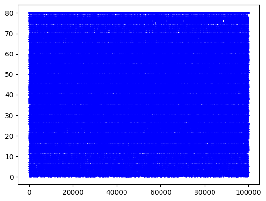

Output

```
Outliers in column  age  are:  set()
```

Output

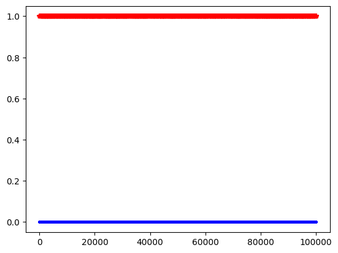

Output

```
Outliers in column  hypertension  are:  {1}
```

Output

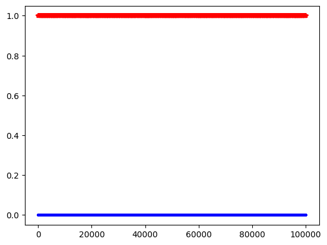

Output

```
Outliers in column  heart_disease  are:  {1}
```

Output

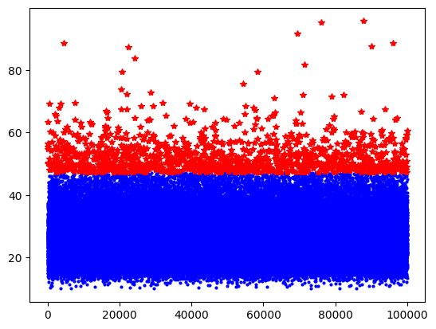

Output

[output not shown]

Output

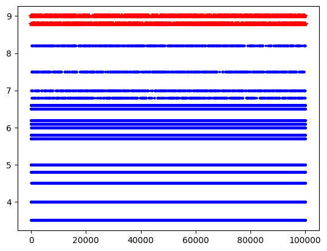

Output

```
Outliers in column  HbA1c_level  are:  {8.8, 9.0}
```

Output

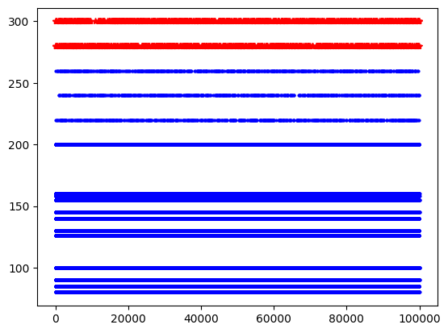

Output

```
Outliers in column  blood_glucose_level  are:  {280, 300}
```

ii) Outlier detection using KNN

Now, we use the k-nearest neighbours method to detect the outliers

```
'''
First, we define a function to find the outlier and
plot the data after highlighting the outliers
'''
%matplotlib inline
def knn_outliers(data, threshold, n_neighbors):
    nbrs = NearestNeighbors(n_neighbors = 10)
    X = data.reshape(-1, 1)
    # fit model
    nbrs.fit(X)
    # distances and indexes of k-neaighbors from model outputs
    distances, indexes = nbrs.kneighbors(X)
    # plot mean of k-distances of each observation
    plt.plot(distances.mean(axis = 1))
    # visually determine cutoff values > 0.15
    outlier_index = np.where(distances.mean(axis = 1) > threshold)
    knn_outliers = list(outlier_index[0])
    plt.plot(data, color='blue', marker='o', ms = 2, linewidth = 0)
    plt.plot(data, markevery = knn_outliers, color='green', marker='s', ms=7, fillstyle='none', linewidth=0)
    plt.show()
    outliers = X[knn_outliers]
    return np.unique(outliers)
```

```
'''
TODO: now, we iterate over the columns and find the outliers in each column
'''
dataTypeSeries = df_pid.dtypes
for col_idx in range(len(df_pid.columns)-1):
    if (not (dataTypeSeries[col_idx] == 'object')):
        current_attribute = df_pid.columns[col_idx]
        cur_att_values = np.array(df_pid[current_attribute])
        outliers = knn_outliers(cur_att_values, 0.75, 10)
        print("Attribute {} has {} as outliers".format(current_attribute, outliers))
```

stderr

```
/var/folders/7c/thwjjxtx3_n8jl9xncdtz7rc0000gq/T/ipykernel_28959/1748342502.py:6: FutureWarning: Series.__getitem__ treating keys as positions is deprecated. In a future version, integer keys will always be treated as labels (consistent with DataFrame behavior). To access a value by position, use `ser.iloc[pos]`
  if (not (dataTypeSeries[col_idx] == 'object')):
```

Output

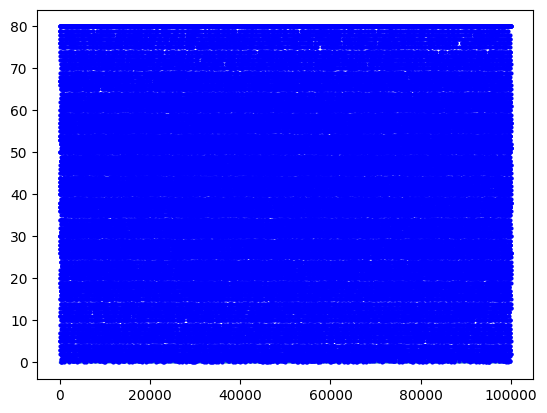

Output

```
Attribute age has [] as outliers
```

stderr

```
/var/folders/7c/thwjjxtx3_n8jl9xncdtz7rc0000gq/T/ipykernel_28959/1748342502.py:6: FutureWarning: Series.__getitem__ treating keys as positions is deprecated. In a future version, integer keys will always be treated as labels (consistent with DataFrame behavior). To access a value by position, use `ser.iloc[pos]`
  if (not (dataTypeSeries[col_idx] == 'object')):
```

Output

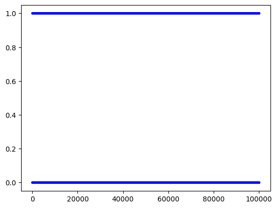

Output

```
Attribute hypertension has [] as outliers
```

stderr

```
/var/folders/7c/thwjjxtx3_n8jl9xncdtz7rc0000gq/T/ipykernel_28959/1748342502.py:6: FutureWarning: Series.__getitem__ treating keys as positions is deprecated. In a future version, integer keys will always be treated as labels (consistent with DataFrame behavior). To access a value by position, use `ser.iloc[pos]`
  if (not (dataTypeSeries[col_idx] == 'object')):
```

Output

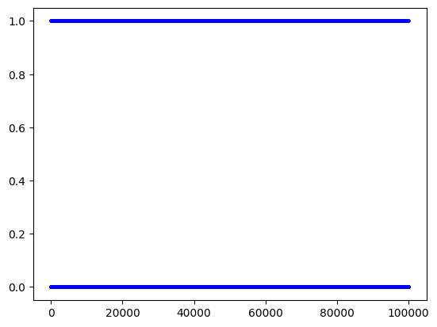

Output

```
Attribute heart_disease has [] as outliers
```

stderr

```
/var/folders/7c/thwjjxtx3_n8jl9xncdtz7rc0000gq/T/ipykernel_28959/1748342502.py:6: FutureWarning: Series.__getitem__ treating keys as positions is deprecated. In a future version, integer keys will always be treated as labels (consistent with DataFrame behavior). To access a value by position, use `ser.iloc[pos]`
  if (not (dataTypeSeries[col_idx] == 'object')):
```

Output

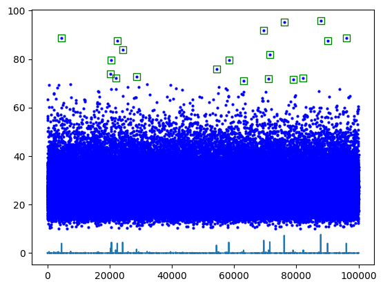

Output

```
Attribute bmi has [70.96 71.55 72.03 72.21 72.28 72.89 73.77 75.78 79.46 79.48 81.73 83.74
 87.51 87.7  88.72 88.76 91.82 95.22 95.69] as outliers
```

stderr

```
/var/folders/7c/thwjjxtx3_n8jl9xncdtz7rc0000gq/T/ipykernel_28959/1748342502.py:6: FutureWarning: Series.__getitem__ treating keys as positions is deprecated. In a future version, integer keys will always be treated as labels (consistent with DataFrame behavior). To access a value by position, use `ser.iloc[pos]`
  if (not (dataTypeSeries[col_idx] == 'object')):
```

Output

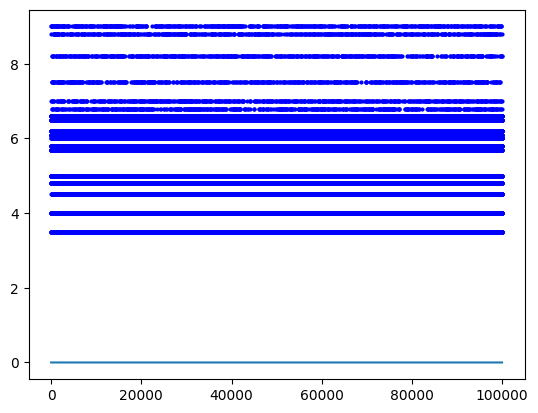

Output

```
Attribute HbA1c_level has [] as outliers
```

stderr

```
/var/folders/7c/thwjjxtx3_n8jl9xncdtz7rc0000gq/T/ipykernel_28959/1748342502.py:6: FutureWarning: Series.__getitem__ treating keys as positions is deprecated. In a future version, integer keys will always be treated as labels (consistent with DataFrame behavior). To access a value by position, use `ser.iloc[pos]`
  if (not (dataTypeSeries[col_idx] == 'object')):
```

Output

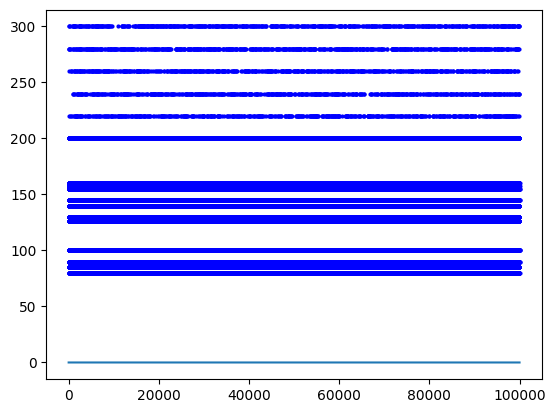

Output

```
Attribute blood_glucose_level has [] as outliers
```

iii) Outlier detection using Local Outlier Factor

Now, we use the LOF method to detect the outliers

```
'''
TODO: Apply LOF to find outliers in all the columns in the dataframe except the label
'''
from sklearn.neighbors import LocalOutlierFactor
%matplotlib inline

def lof_outliers(data, threshold):
    clf = LocalOutlierFactor(n_neighbors = 10)
    X = data.reshape(-1, 1)
    clf.fit_predict(X)
    lofOutiers = []
    for cc in range(len(clf.negative_outlier_factor_)):
        if clf.negative_outlier_factor_[cc] < -threshold:
            lofOutiers.append(cc)
    plt.plot(data, color='blue', marker='*', ms=6, linewidth=0)
    plt.plot(data, markevery = lofOutiers, color='red', marker='s', ms=9, \
             fillstyle='none', linewidth=0)
    plt.show()
    outliers = X[lofOutiers]
    return np.unique(outliers)
```

```
'''
TODO: now, we iterate over the columns and find the outliers in each column
'''
dataTypeSeries = df_pid.dtypes
for col_idx in range(len(df_pid.columns)-1):
    if (not (dataTypeSeries[col_idx] == 'object')):
        current_attribute = df_pid.columns[col_idx]
        cur_att_values = np.array(df_pid[current_attribute])
        outliers = lof_outliers(cur_att_values, 1.0)
        print("Attribute {} has {} as outliers".format(current_attribute, outliers))
```

stderr

```
/var/folders/7c/thwjjxtx3_n8jl9xncdtz7rc0000gq/T/ipykernel_28959/2169311699.py:6: FutureWarning: Series.__getitem__ treating keys as positions is deprecated. In a future version, integer keys will always be treated as labels (consistent with DataFrame behavior). To access a value by position, use `ser.iloc[pos]`
  if (not (dataTypeSeries[col_idx] == 'object')):
```

Output

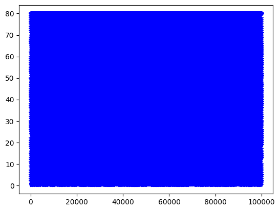

Output

```
Attribute age has [] as outliers
```

stderr

```
/var/folders/7c/thwjjxtx3_n8jl9xncdtz7rc0000gq/T/ipykernel_28959/2169311699.py:6: FutureWarning: Series.__getitem__ treating keys as positions is deprecated. In a future version, integer keys will always be treated as labels (consistent with DataFrame behavior). To access a value by position, use `ser.iloc[pos]`
  if (not (dataTypeSeries[col_idx] == 'object')):
```

Output

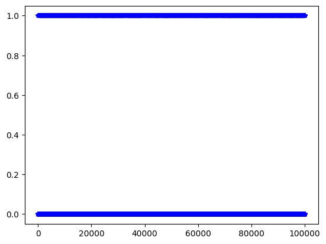

Output

```
Attribute hypertension has [] as outliers
```

stderr

```
/var/folders/7c/thwjjxtx3_n8jl9xncdtz7rc0000gq/T/ipykernel_28959/2169311699.py:6: FutureWarning: Series.__getitem__ treating keys as positions is deprecated. In a future version, integer keys will always be treated as labels (consistent with DataFrame behavior). To access a value by position, use `ser.iloc[pos]`
  if (not (dataTypeSeries[col_idx] == 'object')):
```

Output

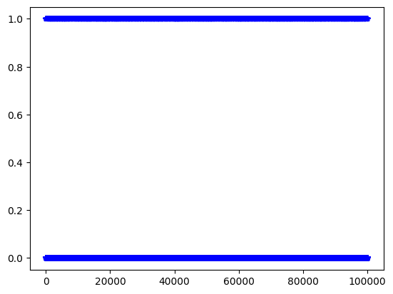

Output

```
Attribute heart_disease has [] as outliers
```

stderr

```
/var/folders/7c/thwjjxtx3_n8jl9xncdtz7rc0000gq/T/ipykernel_28959/2169311699.py:6: FutureWarning: Series.__getitem__ treating keys as positions is deprecated. In a future version, integer keys will always be treated as labels (consistent with DataFrame behavior). To access a value by position, use `ser.iloc[pos]`
  if (not (dataTypeSeries[col_idx] == 'object')):
/Users/hakim/Documents/gen_env/lib/python3.10/site-packages/sklearn/neighbors/_lof.py:322: UserWarning: Duplicate values are leading to incorrect results. Increase the number of neighbors for more accurate results.
  warnings.warn(
```

Output

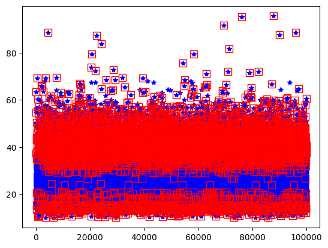

stderr

```
/var/folders/7c/thwjjxtx3_n8jl9xncdtz7rc0000gq/T/ipykernel_28959/2169311699.py:6: FutureWarning: Series.__getitem__ treating keys as positions is deprecated. In a future version, integer keys will always be treated as labels (consistent with DataFrame behavior). To access a value by position, use `ser.iloc[pos]`
  if (not (dataTypeSeries[col_idx] == 'object')):
```

Output

```
Attribute bmi has [10.01 10.08 10.14 ... 91.82 95.22 95.69] as outliers
```

Output

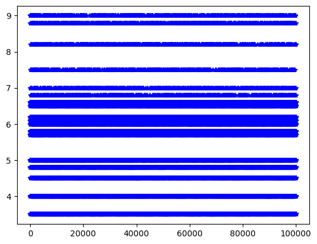

Output

```
Attribute HbA1c_level has [] as outliers
```

stderr

```
/var/folders/7c/thwjjxtx3_n8jl9xncdtz7rc0000gq/T/ipykernel_28959/2169311699.py:6: FutureWarning: Series.__getitem__ treating keys as positions is deprecated. In a future version, integer keys will always be treated as labels (consistent with DataFrame behavior). To access a value by position, use `ser.iloc[pos]`
  if (not (dataTypeSeries[col_idx] == 'object')):
```

Output

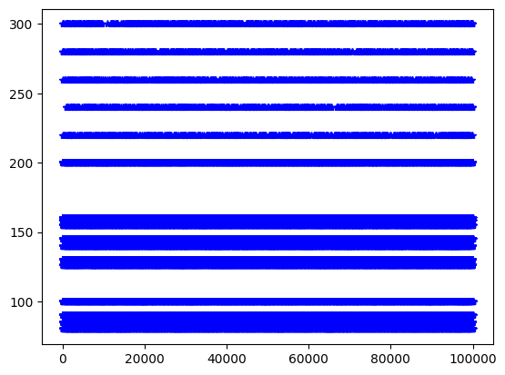

Output

```
Attribute blood_glucose_level has [] as outliers
```